# 禅中看缠 (Zen Plugin) — 用户手册 V1.4

> **授人以鱼，不如授人以渔。**一个**严格遵循**缠论原著理论框架、又**支持自定义**配置细节的缠论学习研究工具。

## 目录

- 第一部分：通达信 DLL 插件（Windows）
  - 1.1 安装与部署
    - 1.1.1 第一阶段：下载并安装通达信
    - 1.1.2 第二阶段：部署禅中看缠插件
    - 1.1.3 第三阶段：导入缠论公式
    - 1.1.4 卸载插件
  - 1.2 首次运行与授权
    - 1.2.1 获取机器码
    - 1.2.2 完成授权
  - 1.3 公式使用方法
    - 1.3.1 功能索引
      - 1.3.1.1 完整组合表
    - 1.3.2 绘图公式
      - 1.3.2.1 指标参数设置
      - 1.3.2.2 信号代码含义
    - 1.3.3 插件选股（极速选股）
      - 1.3.3.1 参数配置表
      - 1.3.3.2 跨级别组合选股（多周期共振）
  - 1.4 关于绘图公式
    - 1.4.1 funcid 功能索引
    - 1.4.2 常用公式配置组合
    - 1.4.3 关于缠论分析的 K 线数量
  - 1.5 禅中看缠回测工具
    - 1.5.1 适用场景
    - 1.5.2 授权与试用
    - 1.5.3 使用方法
    - 1.5.4 分析参数
    - 1.5.5 逐根推送与整体推送
    - 1.5.6 交易模拟（买卖回测）
- 第二部分：桌面版
  - 2.1 安装与部署
  - 2.2 首次运行与授权
    - 2.2.1 获取机器码
    - 2.2.2 完成授权
    - 2.2.3 试用期说明
  - 2.3 界面说明
    - 2.3.1 开关说明
    - 2.3.2 周期切换与自选股
    - 2.3.3 K线图操作
  - 2.4 数据源
- 第三部分：安卓版
  - 3.1 安装与部署
  - 3.2 首次运行与授权
    - 3.2.1 获取机器码与完成授权
  - 3.3 界面说明
    - 3.3.1 K线图操作
- 附录
  - 附录 A.1 模式开关详解
  - 附录 A.2 授权等级
  - 附录 A.3 通达信 DLL 绑定说明
  - 附录 A.4 通达信盘后数据下载说明

## 第一部分：通达信 DLL 插件（Windows）

### 1.1 安装与部署

**版本兼容说明**

本插件基于通达信公式系统的公开插件接口开发，兼容标准：内核 7.42 及以上、且**未禁用 DLL 绑定功能的 Windows 版本**。

- 官网版通达信金融终端 7.42+：完整支持（32/64 位）
- 券商定制版：（部分举例）华泰证券、国泰君安、中信证券、银河证券、招商证券、广发证券、海通证券、中信建投、国信证券、平安证券、中金财富、长江证券、东方证券、兴业证券等都与通达信有合作版本，理论上也可以使用本插件；但大部分头部券商使用自有品牌名和主程序名（如中信`ecitic.exe`、招商`newone.exe`等），但整体目录架构其实是类似的。注意：自动安装脚本仅支持主程序名为`tdxw.exe`的标准版本，若主程序已改名请按「方法二」手工安装。另外，**可能部分券商对插件绑定功能做了限制或阉割，那就无法使用本插件**。无法确定所用券商版是否兼容时，直接按「方法二」手工安装后测试：主图能正常显示缠论分析即为兼容，提示 TDXDLL2 相关错误则该版本不支持。
- 不支持：非通达信内核的行情软件（同花顺、东方财富等）及移动版，券商定制的通达信版本中阉割掉插件绑定功能的也不支持。

#### 1.1.1 第一阶段：下载并安装通达信

从通达信官网下载并安装通达信金融终端（需 7.42 及以上版本）。目前主流电脑**推荐使用 64 位版本**。

[figure not shown]

下载 32 位通达信后是下图的第一个文件，下载 64 位通达信（推荐）则是下图的第二个文件。

32 位和 64 位版本的通达信只需要下载一个双击安装即可，不要都装。**安装路径请注意尽量不要包含中文字符**，最好就用其默认提供的路径。如果想装到其他盘符（如 D:、E:），在安装时修改路径头部字母即可。

- 32 位通达信默认安装在 `C:\new_tdx`
- 64 位通达信默认安装在 `C:\new_tdx64`

[figure not shown]

[figure not shown]

#### 1.1.2 第二阶段：部署禅中看缠插件

本插件提供**自动安装（推荐）**和**手工安装**两种方式，最终效果完全相同。无论选择哪种方式，安装完成后都必须继续阅读下一节 1.1.3 第三阶段：导入缠论公式 完成最后的公式导入。

##### 方法一：自动安装（推荐）

安装脚本会自动完成插件文件的复制部署与插件绑定（操作步骤参见下方「方法二」），无需手动定位目录、复制文件或配置绑定。

注意事项：

- 安装脚本会**自动请求管理员权限**（双击运行后弹出"用户账户控制"提示时点击"是"即可），因为它要向通达信的系统目录写入文件并创建子目录。没有管理员权限会被 Windows 拒绝。

操作步骤：

1. 从发布页面下载插件压缩包并解压。（最好避免路径中出现中文）**请注意选择与通达信版本匹配的插件**（32 位或 64 位），否则无法使用。
2. 找到并**双击**运行 `双击我_进行安装或升级.bat`，若弹出"用户账户控制"提示时点击 **"是"**。脚本会自动识别当前DLL插件版本并匹配对应的通达信。
3. 安装脚本会通过多种策略自动搜索系统中通达信的安装位置，自动完成插件文件的复制、绑定与逐字节校验。（通达信或位数不匹配时会提示手动选择，请按提示手工输入 `32` 或 `64`）**必须看到脚本最后的 "安装/升级完成!" 提示才算成功**，然后按任意键关闭窗口。
   - 如果窗口**一闪而过**或中途报错退出，说明安装没有成功，请改按下方「方法二：手工安装」完成安装。
4. 脚本会自动完成 DLL 插件与通达信的绑定（`dlls.ini` 已放入通达信下的 `T0002\dlls` 目录），**无需再手工绑定**；接下来的公式导入请继续阅读 1.1.3 第三阶段：导入缠论公式。
5. 升级安装的用户可确认版本号：登录通达信时留意授权弹窗左上角显示的版本号；或按「方法二」找到 `tdx_zen.dll` 所在目录，右键该文件 → 属性 → 详细信息查看"文件版本"。

##### 方法二：手工安装

1. 从发布页面下载插件压缩包并解压。（最好避免路径中出现中文）**请注意选择与通达信版本匹配的插件**（32 位或 64 位），否则无法使用。
2. 将压缩包内的 `tdx_zen.dll`，`dlls.ini`，`tdx_zen.tn6` 3个文件都复制到通达信安装目录下的 `T0002\dlls\` 子目录中：
   - 例如：`C:\new_tdx\T0002\dlls\`（32 位）
   - 或者：`C:\new_tdx64\T0002\dlls\`（64 位）
3. 将压缩包内的 `tdx_zen.dll` 文件同时复制到通达信安装目录下的 `plugin` 子目录下，**如果没有此目录请手工新建**。注意该 `plugin` 目录是和 `T0002` 目录平行的，不要建在 `T0002` 下面。
   - 例如：`C:\new_tdx\plugin\`（32 位）
   - 或者：`C:\new_tdx64\plugin\`（64 位）
4. 将 `zen_license.key` 授权文件（**3 天免费试用不需要此步骤**，获得正式授权时再进行此步骤）放到通达信安装目录下的上述 `T0002\dlls` 和 `plugin` 两个子目录下，也就是和插件文件 `tdx_zen.dll` 要在同一目录里。

#### 1.1.3 第三阶段：导入缠论公式

上节如果已经把 `dlls.ini` 文件放到了 `dlls` 目录，插件的绑定工作已经自动完成（自动安装方式同样已由脚本完成绑定）。如果因为通达信版本功能变化绑定没有成功，请参照 附录 A.3 通达信 DLL 绑定说明 进行手工绑定。

1. 启动通达信软件，按下 **`Ctrl + F`** 打开公式管理器。
2. 点击右侧的 **"导入公式"** 按钮，选中上节 `dlls` 目录下的 `tdx_zen.tn6` 文件导入；**升级安装时同样需要重新导入** `tdx_zen.tn6` 并覆盖同名公式。

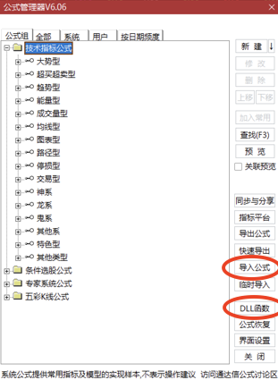

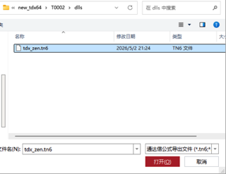

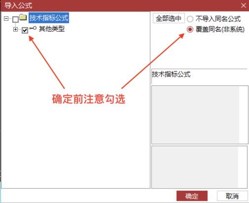

3. 导入缠论主图公式（名为 `ZEN`），在行情界面输入该公式名称即可使用。

[figure not shown]

#### 1.1.4 卸载插件

当不需要此插件时按照下述步骤从电脑中彻底移除。

1. 删除 `T0002\dlls\` 下的 `tdx_zen.dll`、`dlls.ini` 和 `zen_license.key` 文件（如有）。
2. 删除通达信安装目录下 `plugin\` 中的 `tdx_zen.dll` 和 `zen_license.key` 文件（如有）。
3. 公式管理器中（按下 **`Ctrl + F`**）删除已导入的缠论公式 'ZEN'。

⬆ 回到目录

### 1.2 首次运行与授权

完成了 1.1 节的安装后就可以重启通达信了，登录时会有如下弹窗（通过浏览器打开的页面，请注意是否在状态栏中）：

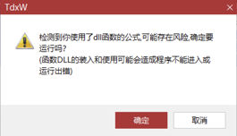

需要**连续点击两次确认**进入通达信主界面。插件是通达信官方允许的拓展模式，但是会提醒用户知晓正在使用插件。

登录后，首次运行会有如下弹窗协议，必须**滚动到协议最后阅读全文点击同意**后方可继续使用。如果点击取消或者关闭该弹窗页面将视为不同意，无法继续使用。如果不小心关闭了弹窗，重新启动登录通达信即可再次出现。一旦点击了同意将不再显示该协议。

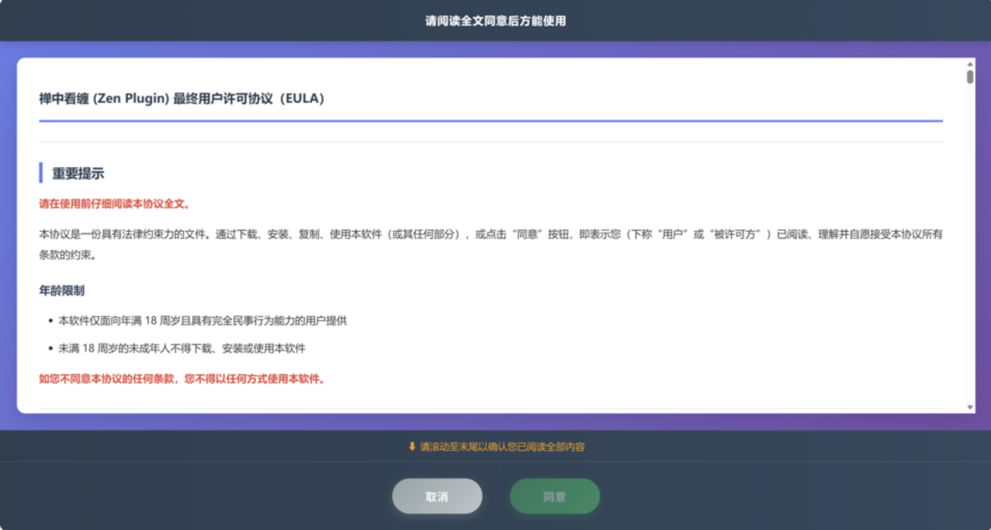

如果你的电脑没有弹出协议，或者无法点击同意按钮等问题，请加入QQ群（压缩包内的 README.html 文件中有群号）向作者询问如何跳过协议进入系统（作者邮箱以软件授权弹窗中显示为准）。

#### 1.2.1 获取机器码

试用期间，插件每天会自动弹窗显示机器码一次（格式 `zen-xxxxxxxx-xxxxxxxx`），机器码会自动复制到剪贴板。将机器码发送给作者获取授权文件。如果有授权文件，该授权到期前7天也每天提醒一次，其它时间不会弹窗干扰客户使用。

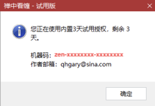

#### 1.2.2 完成授权

将获取到的 `zen_license.key` 授权文件放到 `T0002\dlls\` 和 `plugin` 目录下（与 DLL 文件在同一目录），重新打开通达信即可生效。`T0002\dlls\` 用于主图分析，`plugin\` 用于插件选股，两个目录都需要放置 `zen_license.key`。

> **试用期**：无授权文件时，可无限制使用 **3 天试用期**。请注意，一旦放入授权文件，试用期立即结束，无法再回到试用模式。

⬆ 回到目录

### 1.3 公式使用方法

> 使用默认配置即可，不准备修改模式的可以忽略本章节的详细说明。

#### 1.3.1 功能索引

公式的 **MODE** 参数可根据下文自行修改，通过 MODE 可以控制各个开关达到自定义插件功能的目的。看不懂或者不知道用哪个的建议使用默认值。

**`MODE = 9000 + 位掩码`**：

| 比特位 | 掩码 | 功能 | 说明 |
| --- | --- | --- | --- |
| bit0 | 1 | 缺口成笔 | 极点间存在跳空缺口且新笔破坏前一笔方向时，不受最少K线数限制直接成笔 |
| bit1 | 2 | 新笔成笔 | 顶底极点之间原始K线≥3且独立K线≥4（顶底分型不共用K线）即可成笔，不要求独立K线≥5。适用于K线密集包含关系较多、独立K线偏少但价格波动已满足笔的区间要求的场景 |
| bit2 | 4 | 拓展 | 元素离开中枢后，在没有形成新中枢前又回到原中枢。一直在中枢范围内会被自动纳入，不属于此拓展（无法关闭） |
| bit3 | 8 | 扩张（自动开启拓展） | 波动区间触碰时合并为更高级别中枢。扩张以拓展为前提：拓展是中枢的横向延伸，扩张是纵向合并＋横向延伸的复合操作，二者底层逻辑一致，引擎会自动维护依赖关系 |
| bit4 | 16 | 跨界 | 允许笔中枢跨越线段边界进行延伸和扩张，线段中枢不受此约束。开启后信号更少 |

> **扩张与拓展的联动规则**（replay / desktop / apk 通用）：
> - **打开扩张时**，如果拓展未开，会自动强制打开拓展。若拓展本身已开则无影响。
> - **关闭拓展时**，如果此时扩张是开的，会自动强制关闭扩张（因为扩张依赖拓展）。
> - **关闭扩张时**，不影响拓展状态（拓展可独立存在）。

> 扩张以拓展为前提的原因：拓展是中枢的横向延伸（同级别内回中枢则纳入本体），扩张是纵向合并＋横向延伸的复合操作，底层逻辑上扩张包含了拓展的行为，因此不允许"开扩张但关拓展"的组合存在。

> 默认关闭扩张纯粹是为了在本周期中看清笔中枢的细节结构——扩张升级后的中枢可以到高一级别的周期中查看，本周期看到的就是细节本身；打开扩张会将这些细节合并吃掉。

> 因此，下表中灰色文字的 MODE（9008–9011、9024–9027，即扩张开但拓展关）实际不可能存在——引擎会自动将拓展强制打开，等价于拓展已开的对应模式（9012–9015、9028–9031）。请不要在通达信中手动设置这些灰色 MODE 值。

##### 1.3.1.1 完整组合表

| MODE | 掩码 | 缺口 | 新笔 | 拓展 | 扩张 | 跨界 |
| --- | --- | --- | --- | --- | --- | --- |
| 9000 | 0 | ❌ | ❌ | ❌ | ❌ | ❌ |
| 9001 | 1 | ✅ | ❌ | ❌ | ❌ | ❌ |
| 9002 | 2 | ❌ | ✅ | ❌ | ❌ | ❌ |
| 9003 | 3 | ✅ | ✅ | ❌ | ❌ | ❌ |
| **9004** | **4** | ❌ | ❌ | ✅ | ❌ | ❌ |
| 9005 | 5 | ✅ | ❌ | ✅ | ❌ | ❌ |
| 9006 | 6 | ❌ | ✅ | ✅ | ❌ | ❌ |
| 9007 | 7 | ✅ | ✅ | ✅ | ❌ | ❌ |
| 9008 | 8 | ❌ | ❌ | ❌ | ✅ | ❌ |
| 9009 | 9 | ✅ | ❌ | ❌ | ✅ | ❌ |
| 9010 | 10 | ❌ | ✅ | ❌ | ✅ | ❌ |
| 9011 | 11 | ✅ | ✅ | ❌ | ✅ | ❌ |
| 9012 | 12 | ❌ | ❌ | ✅ | ✅ | ❌ |
| 9013 | 13 | ✅ | ❌ | ✅ | ✅ | ❌ |
| 9014 | 14 | ❌ | ✅ | ✅ | ✅ | ❌ |
| 9015 | 15 | ✅ | ✅ | ✅ | ✅ | ❌ |
| 9016 | 16 | ❌ | ❌ | ❌ | ❌ | ✅ |
| 9017 | 17 | ✅ | ❌ | ❌ | ❌ | ✅ |
| 9018 | 18 | ❌ | ✅ | ❌ | ❌ | ✅ |
| 9019 | 19 | ✅ | ✅ | ❌ | ❌ | ✅ |
| 9020 | 20 | ❌ | ❌ | ✅ | ❌ | ✅ |
| 9021 | 21 | ✅ | ❌ | ✅ | ❌ | ✅ |
| 9022 | 22 | ❌ | ✅ | ✅ | ❌ | ✅ |
| 9023 | 23 | ✅ | ✅ | ✅ | ❌ | ✅ |
| 9024 | 24 | ❌ | ❌ | ❌ | ✅ | ✅ |
| 9025 | 25 | ✅ | ❌ | ❌ | ✅ | ✅ |
| 9026 | 26 | ❌ | ✅ | ❌ | ✅ | ✅ |
| 9027 | 27 | ✅ | ✅ | ❌ | ✅ | ✅ |
| 9028 | 28 | ❌ | ❌ | ✅ | ✅ | ✅ |
| 9029 | 29 | ✅ | ❌ | ✅ | ✅ | ✅ |
| 9030 | 30 | ❌ | ✅ | ✅ | ✅ | ✅ |
| 9031 | 31 | ✅ | ✅ | ✅ | ✅ | ✅ |

> 新笔成笔与缺口成笔互不影响，满足其一即可成笔。

> 上表中灰色背景的 MODE 即上文所述"扩张开但拓展关"的不可能组合（会自动等价于拓展已开的对应模式），请勿手动设置。

> **默认模式 9004**：仅开启拓展，缺口成笔/新笔成笔/扩张/跨界均关闭。这是代码内置的默认配置，采用严格笔定义。看不懂或者不知道用哪个的建议直接使用默认值。

#### 1.3.2 绘图公式

在通达信中，绘图公式用于在行情界面显示缠论分析效果。输入公式名称 `ZEN` 即可在主图上显示完整的缠论分析结果。

##### 1.3.2.1 指标参数设置

公式有三个参数可供调整：

| 参数 | 说明 | 默认值 |
| --- | --- | --- |
| **MODE** | 分析模式选择，控制各个开关的组合（见上文） | 9004 |
| **PMODE** | 处理模式选择：1=逐根推送（默认），0=整体推送 | 1 |
| **USEORIGINALK** | 笔落点：0=缠论K线（默认），1=原始K线 | 0 |

**PMODE 处理模式说明**：

可通过通达信原生的"指标参数修改"对话框动态切换 PMODE 参数（部分版本可通过 **Alt+T** 调出），切换后立即生效（自动清空分析缓存并重新计算）。

**USEORIGINALK 笔落点说明**：

- `0`（默认）：笔的落点为缠论 K 线（包含关系合并处理后）的极值。
- `1`：笔绘制的落点基于原始 K 线的最大/最小值，而非合并后的缠论 K 线。

该参数满足有此类显示需求的用户；但落点改变后，依赖于笔的线段、中枢等后续缠论分析结论都可能随之变化，没有此需求请保持默认值。注意 K 线合并、分型识别、缺口成笔判定等流程始终使用合并 K 线，该参数仅改变笔端点的取价。

**与绘制开关 V_K_HB 的区别**：`V_K_HB` 只影响显示层面——绘制原始 K 线还是缠论 K 线，不改变任何缠论分析结果；而 `USEORIGINALK` 会改变笔的落点，后续依赖于笔的所有缠论分析结论都可能受其影响。另外，`USEORIGINALK=1` 时公式中的缠论合并 K 线绘制段自动失效，无论 `V_K_HB` 取值如何都显示原始 K 线；只有 `USEORIGINALK=0` 时 `V_K_HB` 才生效。

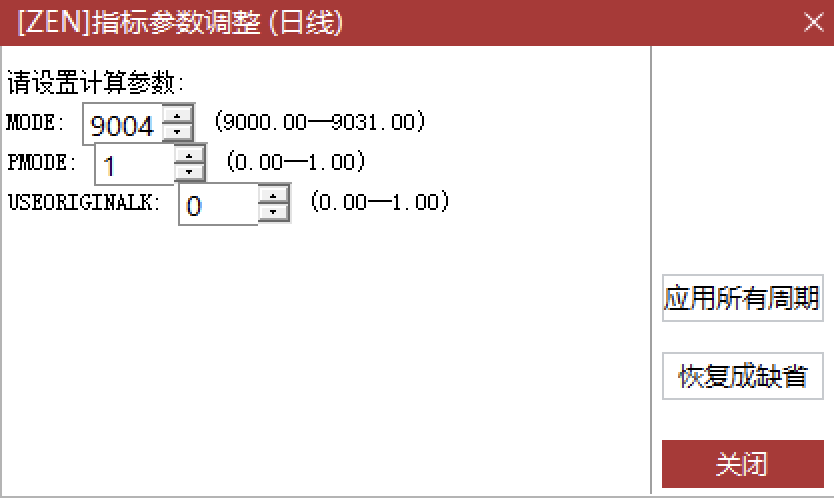

##### 1.3.2.2 信号代码含义

公式中各信号的含义如下：

**笔信号（funcid=218）**：

| 信号代码 | 含义 |
| --- | --- |
| 1B | 笔一买 |
| 2B | 笔二买 |
| 3B | 笔三买 |
| 23B | 笔二三买合并 |
| 1S | 笔一卖 |
| 2S | 笔二卖 |
| 3S | 笔三卖 |
| 23S | 笔二三卖合并 |
| 底背驰(弱/中/强) | 笔底背驰信号 |
| 顶背驰(弱/中/强) | 笔顶背驰信号 |
| 盘整背驰(弱/中/强) | 笔盘整背驰信号 |

**线段信号（funcid=228）**：

| 信号代码 | 含义 |
| --- | --- |
| 1B-XD | 线段一买 |
| 2B-XD | 线段二买 |
| 3B-XD | 线段三买 |
| 23B-XD | 线段二三买合并 |
| 1S-XD | 线段一卖 |
| 2S-XD | 线段二卖 |
| 3S-XD | 线段三卖 |
| 23S-XD | 线段二三卖合并 |
| 底背驰-XD(弱/中/强) | 线段底背驰信号 |
| 顶背驰-XD(弱/中/强) | 线段顶背驰信号 |
| 盘整背驰-XD(弱/中/强) | 线段盘整背驰信号 |

**MACD背离信号（funcid=301）**：

| 信号代码 | 含义 |
| --- | --- |
| MACD底背(弱/中/强) | MACD 底背离信号 |
| MACD顶背(弱/中/强) | MACD 顶背离信号 |

> MACD 背离是独立于缠论走势分析的额外信号，不需要缠论中枢/买卖点理论支持，仅依赖 MACD 指标自身的背离判断。即使在公式中不使用缠论走势分析函数，只要拥有走势版授权，MACD 背离信号仍可正常显示。

**背驰强度说明**：

| 强度代码 | 含义 |
| --- | --- |
| 弱 | 弱背驰 |
| 中 | 中等背驰 |
| 强 | 强背驰 |

#### 1.3.3 插件选股（极速选股）

使用插件选股功能前，必须先将股票数据下载到本地（具体下载方法见 附录 A.4 通达信盘后数据下载说明），否则无法选出任何股票。

点击通达信右上角"公式"下方的插件选股即可使用，点击后弹出插件选股界面，支持多级别、多信号的组合筛选。注意一下关于复权勾选框的图示提醒。

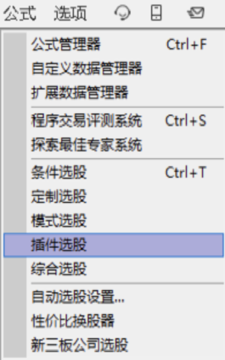

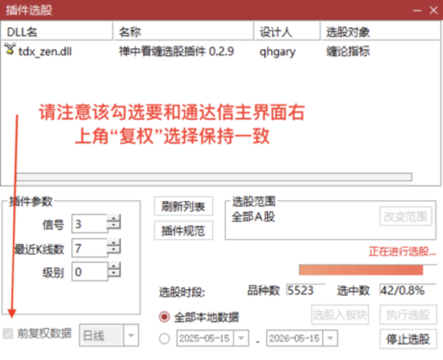

如果离线数据并非最新，请先下载完整后（日K+5分钟）再运行，否则选股弹窗中的"最近K线数"找到的信号可能超过设置值，因为插件是把离线数据当做最新数据进行分析搜索的。

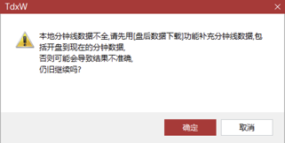

> **注意**：插件选股同样需要**选股功能授权**，如果证书缺少选股功能位，即便打开界面执行选股，也无法选出任何股票。

**数据范围选择**：插件选股支持两种数据范围模式，通过界面右侧的**范围**选择控件切换：

| 模式 | 说明 |
| --- | --- |
| **全部** | 使用全部本地数据进行选股，"最近K线数量"的参照点为**最新数据（今天）**（默认模式） |
| **区间** | 仅在用户指定的日期区间内进行选股，"最近K线数量"的参照点为**区间结束日** |

两种模式的参数含义和信号类型完全一致，核心区别在于**"最近K线数量"的参照点不同**：

- **全部**：信号出现在离今天 N 根 K 线内即命中
- **区间**：信号出现在离**区间结束日** N 根 K 线内才命中（区间起始日之前的数据不参与分析）

> **使用场景示例**：区间选股适合历史回溯——如"查看 2025 年 1 月期间哪些股票出现过三买信号"，只需将区间设为 2025-01-01 ~ 2025-01-31，插件就只分析该月数据，并以 1 月 31 日为参照点在最近 N 根 K 线内搜索信号。

> **注意**：使用区间选股时，先在范围选择控件中设定好日期区间，再执行选股。

##### 1.3.3.1 参数配置表

在插件选股界面中，你可以通过修改参数，灵活指定筛选类型。

| 参数名称 | 可选数值 / 含义说明 |
| --- | --- |
| **信号** | `1`:一买, `2`:二买, `3`:三买, `23`:二三买合并, `4`:中枢底背驰, `5`:MACD底背离, `6`:向下笔/线段端点 `-1`:一卖, `-2`:二卖, `-3`:三卖, `-23`:二三卖合并, `-4`:中枢顶背驰, `-5`:MACD顶背离, `-6`:向上笔/线段端点。默认 `3` |
| **最近K线数量** | 选出最近 N 根 K 线内出现过上述信号的股票。默认 `7` |
| **级别** | `0`: 笔级别信号 `1`: 线段级别信号。默认 `0` （当信号选择 ±5 筛选 MACD 顶底背离时，级别无论选择 0 或 1 不影响结果） |

> **±6 端点信号说明**：信号 `+6` 代表向下笔/线段的端点（与买点相关，故用正数），`-6` 代表向上笔/线段的端点（与卖点相关，故用负数）。级别为 `0` 时搜索笔的端点，级别为 `1` 时搜索线段的端点。端点可以是已确认的，也可以是未确认的（待定/虚拟状态），只要最后一个笔/线段的端点落在最近 N 根 K 线内即命中。

> 选股分析固定使用 420 根 K 线数据计算，与通达信“系统设置 > 分析设置”默认加载的 K 线数保持一致，确保选股分析结果与图表显示一致。

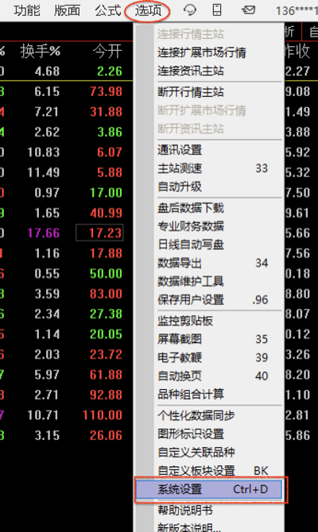

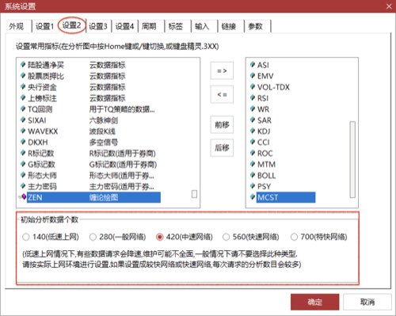

##### 1.3.3.2 跨级别组合选股（多周期共振）

本插件支持极致灵活的跨级别选股，核心思路是：**先用大级别条件筛选出股票存入临时板块，再以此为范围叠加小级别条件进行二次筛选**——两个周期的信号交集即为多周期共振的精确结果（例如：日线底背驰 + 30分钟二买）。

**操作流程**：

1. **第一步（大级别筛选，建立临时板块）**：
   - 将周期选择为较大的级别（如 **"日线"**）。
   - 设置参数：选择你需要的大级别信号（如信号 `4`=底背驰，级别 `0`=笔），最近K线数量填 `10`。
   - 执行选股，完成后将结果**全选 -> 右键加入到板块 -> 新建自定义板块**（例如命名为"日线底背驰"）。
2. **第二步（小级别共振，范围限定）**：
   - 再次打开插件选股，将周期切换为较小的级别（如 **"30分钟"**）。
   - **关键**：将界面右侧的**选股范围**从默认的"A股板块"更改为刚才建立的**临时板块**（如"日线底背驰"）。
   - 设置小级别参数：如信号 `2`（二买），最近K线数量填 `15`（小周期走得快，可适当放宽）。
   - 执行选股——最终结果即为同时满足**大级别条件 AND 小级别条件**的股票。

> **提示**：此方法也可反向使用（小级别初筛 + 大级别精选），或叠加更多层级逐级收敛。临时板块可反复复用——只要其中的股票数据未变，随时可以不同的参数对同一批股票做二次筛选。

⬆ 回到目录

### 1.4 关于绘图公式

> 普通用户可以忽略此章节，直接使用默认公式即可。以下内容面向想高度定制绘图效果的高阶用户。

通达信主图公式以加密形式分发，加密密码为 `33333333`。设置密码的目的仅为防止用户误操作修改公式导致显示异常，并非为了保密。

在通达信的公式管理器中打开 ZEN 主图公式时，输入上述密码即可查看完整源码。公式开头第 0 节为**绘制开关集中控制区**，公式内每一处绘制逻辑均有注释标注（如笔连线、线段连线、笔中枢、线段中枢、买卖点、背驰等）。高阶用户无需改动其它代码，只要修改开头各开关的数值（`1`=绘制 / `0`=隐藏）即可控制对应绘制段的显隐，详见 1.4.2 常用公式配置组合。

**注意事项：**

- 该公式依赖插件 DLL 提供的计算结果，必须与通达信插件配合使用。在未安装插件的环境中——包括未安装插件的通达信、以及安卓版通达信——公式均无法正常工作。
- 关于公式本身的编写细节与自定义方法，请自行研究，或在本项目的 QQ 交流群内提问。

#### 1.4.1 funcid 功能索引

以下是通达信公式中通过 `TDXDLL2(funcid, H, C, L)` 调用的各功能编号及其用途，供高级用户自定义公式时参考：

| funcid | 功能 | 授权 | 说明 |
| --- | --- | --- | --- |
| 105 | 合并K线低点 | 基础版 | 输出 merged_low，符号标记独立性（正=独立, 负=被合并） |
| 106 | 合并K线高点 | 基础版 | 输出 merged_high，配合105绘制缠论合并K线 |
| 110 | 笔连线 | 基础版 | 输出笔的连线价格 |
| 120 | 线段连线 | 基础版 | 输出线段的连线价格 |
| 130 | 笔待定状态 | 基础版 | 输出笔的待定状态掩码（0=确认, 0.5=过渡, 1=待定） |
| 131 | 线段待定状态 | 基础版 | 输出线段的待定状态掩码（0=确认, 0.5=过渡, 1=待定） |
| 210 | 笔中枢 ZG | 中枢版 | 输出笔中枢上沿 |
| 211 | 笔中枢 ZD | 中枢版 | 输出笔中枢下沿 |
| 220 | 线段中枢 ZG | 中枢版 | 输出线段中枢上沿 |
| 221 | 线段中枢 ZD | 中枢版 | 输出线段中枢下沿 |
| 218 | 笔买卖点/背驰 | 走势版 | 输出笔的买卖点和背驰信号 |
| 228 | 线段买卖点/背驰 | 走势版 | 输出线段的买卖点和背驰信号 |
| 301 | MACD背离 | 走势版 | 输出 MACD 顶底背离信号（独立于缠论分析） |
| 800 | 切换逐根推送 | 基础版 | 切换为逐根推送模式（默认），不输出数据 |
| 801 | 切换整体推送 | 基础版 | 切换为整体推送模式，不输出数据 |
| 600 | 笔落点 | 基础版 | 按传入值设置笔落点（0=缠论K线，1=原始K线），不输出数据 |
| 9000~9031 | 配置型 funcid | 基础版 | 通过 funcid 值直接设置分析模式，仅设置参数不输出数据 |

> funcid 9000~9031 与 1.3.1 功能索引 中的 MODE 编码完全对应。

#### 1.4.2 常用公式配置组合

根据需要，可以通过修改公式顶部的绘制开关，只显示/隐藏相关内容：

**完整内容（默认）**： 显示缠论合并K、笔、线段、中枢、买卖点、背驰、MACD背离等全部内容。

**关于缠论合并K线**：由于通达信的限制，无法让其不绘制原始K，因此公式默认先用黑色粗柱覆盖原生K线，再叠加缠论合并K线（独立合并K用实线，被合并原始K用虚线）。若希望显示原生K线，把公式顶部开关区的 `V_K_HB` 改为 `0` 即可（`1`=绘制缠论合并K线，`0`=恢复原生K线显示）。注意：`V_K_HB` 只是显示开关，不改变任何分析结果；笔的落点画在哪种 K 线上由指标参数 `USEORIGINALK` 决定（两者区别详见 1.3.2.1 指标参数设置）。当 `USEORIGINALK=1`（笔落点为原始K线）时，本段绘制自动失效，无论 `V_K_HB` 为 `0` 还是 `1` 都显示原生K线。

**关于笔端点价格**：默认隐藏中，如需显示，把公式顶部开关区的 `V_BI_DD` 改为 `1` 即可在每个笔的端点显示价格（`1`=显示，`0`=隐藏）。

**其余部分如果不要某段显示，直接修改公式顶部开关区中对应开关的数值为 `0` 即可**。公式顶部第 0 节集中了全部 7 个绘制开关，每个开关独立控制一段绘制，互不影响：

| 开关变量 | 控制内容（均与公式头部注释一致） | 默认值 |
| --- | --- | --- |
| `V_K_HB` | 缠论合并K线重绘（原生K线涂黑+重绘；`0`=恢复原生K线显示；`USEORIGINALK=1` 时自动失效） | 1 |
| `V_BI` | 笔（确认笔实线 + 待定笔虚线；`0`=不绘制） | 1 |
| `V_BI_DD` | 笔端点价格（每个笔端点标注价格数字，默认隐藏；`1`=显示） | 0 |
| `V_XD` | 线段（确认线段实线 + 待定线段虚线；`0`=不绘制） | 1 |
| `V_BI_ZS` | 笔中枢及其买卖点/背驰（`0`=全部隐藏） | 1 |
| `V_XD_ZS` | 线段中枢及其买卖点/背驰（`0`=全部隐藏） | 1 |
| `V_MACD_BL` | MACD 底背/顶背（独立于缠论，仅供参考，勿与缠论背驰混淆；`0`=不绘制） | 1 |

> 开关位于公式源码**最顶部第 0 节**，每个开关一行、`1`/`0` 含义均以中文注释逐行标注清楚，方便集中修改控制。将某个开关改为 `0` 的效果等同把该段绘制代码整段注释掉；修改后保存公式并在行情界面重新应用即可生效。注意：笔中枢开关 `V_BI_ZS` 同时控制笔中枢绘制及其买卖点（1B/2B/3B/23B、1S/2S/3S/23S）、趋势背驰与盘整背驰；线段中枢开关 `V_XD_ZS` 同理控制线段中枢、线段买卖点（-XD 系列）与线段背驰。

#### 1.4.3 关于缠论分析的 K 线数量

图表分析所使用的 K 线数量与通达信"系统设置 > 分析设置"中的设置一致，默认加载中间档 420 根。

> **注意**：选股功能固定使用 420 根 K 线数据计算，不受上述"系统设置"影响。

> **注意**：选股界面中的"最近 K 线数量"（默认 7）是另一个层面的概念——它从已加载的 420 根 K 线数据中取最近 N 根筛选信号，与分析数据量不同。

⬆ 回到目录

### 1.5 禅中看缠回测工具

回测工具是通达信插件版的附带工具，用于深入学习缠论分析的全过程。通过加载通达信导出的 txt 格式 K 线数据，可以逐根回放缠论分析的每一步，帮助理解笔、线段、中枢、买卖点等结构是如何随行情演变逐步形成的。

#### 1.5.1 适用场景

- 想直观理解不同 MODE 参数对分析结果的影响
- 想观察缠论结构（笔、线段、中枢、买卖点）的动态形成过程
- 盘后复盘，对照历史行情学习缠论理论

#### 1.5.2 授权与试用

回测工具与通达信插件版**共享授权**：机器码相同，试用期与协议同意状态互通——任一侧试用期到期，另一侧同样无法试用。正式授权时，需将同一份 `zen_license.key` 授权文件分别放到回测工具目录和通达信 DLL 所在目录（见 1.2.2 完成授权），一份授权两处通用，无需单独购买。

#### 1.5.3 使用方法

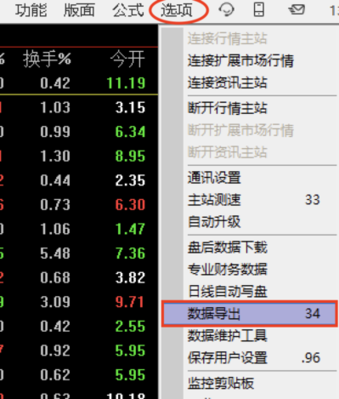

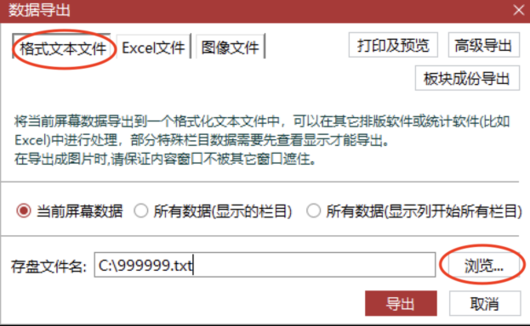

2. 打开回测工具，点击左上角"📂 加载数据"，选择导出的 txt 文件。
3. 加载成功后，顶栏会实时显示统计信息（分型数、笔数、线段数、中枢数、缠论BS点数）。
4. 使用底部播放控制栏进行回放：
   - **⏮ / ⏭**：跳到起点 / 终点
   - **◀◀ / ▶▶**：单步后退 / 前进（也可用键盘 ← →）
   - **▶ 播放**：自动逐根播放（也可用空格键）
   - **速度选择**：可选 0.5x / 1x / 2x / 4x 倍速播放（默认 1x）
   - **数据时间范围**：拖动滑块设定回放的起止范围
   - **十字线**：双击图表显示/隐藏十字线（双击命中笔或线段时优先显示其编号，不切换十字线）。十字线显示后跟随鼠标移动，顶栏同步显示十字线所在 K 线的日期与价格；十字线不会越过最新已回放的 K 线
   - **缩放**：点击 − / + 按钮或键盘 ↑↓ / +−（或 **Ctrl+滚轮**）调整 K 线宽度（默认显示较密集的 K 线，可缩小至更宽视角或放大至更细观察）。未显示十字线时，缩放以当前回放步所在 K 线为中心（其屏幕位置保持不动）；显示十字线后，每级缩放实时将十字线所在 K 线校准至可视区域正中心
   - **平移**：在图表区域拖拽鼠标可左右平移视图；滚轮 / 触控板横滑按步进平移。十字线显示期间拖拽平移暂停（鼠标移动只更新十字线位置）
5. 通过顶部图层面板可勾选显示/隐藏各层结构：缠K、分型、笔、笔端点价格、笔中枢、线段、线段中枢、MACD背离、缠论BS点、中枢背驰。其中分型、笔端点价格默认不显示，其余图层默认开启。
6. 交易模拟：底部交易栏支持按资金比例（25% / 50% / 100%）买入和卖出，可清仓或重置交易记录，实时显示投入仓位、当前收益和总收益。点击图表中的买卖标记会弹出确认菜单，点击"删除此交易"后才会真正删除。双击图表中的笔或线段可显示其编号（从 0 开始），点击旁边区域关闭。

#### 1.5.4 分析参数

回测工具中的分析开关（缺口成笔、新笔成笔、中枢拓展、中枢扩张、允许跨界）与通达信插件版完全一致，含义与推荐设置请参阅 附录 A.1 模式开关详解，完整组合表请参阅 1.3.1.1 完整组合表。顶部有"通达信MODE值"输入框，可直接输入 MODE 数值（如 9004），也可以点击下方开关按钮自动换算，方便与通达信中的参数设置对照。

顶部栏股票代码/周期信息右侧的"笔端点落点"二选一选择器（**缠K落点 / 原K落点**）对应通达信版中的 **USEORIGINALK** 参数：选择"原K落点"后笔端点取原始K线的最高/最低价，选择"缠K落点"则取缠论合并K线的极值（默认）。切换选择后立即按新设置重新分析并重绘全部缠论结构，当前回放步与视图平移位置保持不变。该选择仅影响笔端点取价（K线合并、分型、缺口成笔判定始终使用合并K线），与 MODE 值相互独立，且选择状态会自动保存、下次启动自动恢复。

**与缠K图层的联动**：选择"原K落点"后，图层面板中的"缠K"勾选框会被**禁用**（变灰，但保留之前的勾选状态），图表强制显示原始 K 线——因为笔端点画在原始K线上时，叠加合并K线会与笔端点明显错位。切回"缠K落点"后，"缠K"勾选框重新可用，并按恢复的勾选状态显示合并K线或原始K线。即：绘图用原K落点时显示必定是原始 K 线；只有缠K落点模式下，"缠K"勾选框才用于控制显示合并K线还是原始K线。此联动规则与通达信插件版中 `USEORIGINALK` 对 `V_K_HB` 开关的自动失效逻辑一致。

#### 1.5.5 逐根推送与整体推送

回测工具底部提供"逐根推送"和"整体推送"切换，对应通达信版中的 **PMODE** 参数。两种模式的详细说明请参阅 1.3.2.1 指标参数设置 中的 PMODE 处理模式说明。

> **逐根推送**适合观察每根 K 线加入后缠论结构的动态变化过程，是回测的推荐模式；**整体推送**展示最终的全局分析结果，适合快速查看最终状态。

#### 1.5.6 交易模拟（买卖回测）

回测工具内置交易模拟系统，可结合缠论买卖点信号进行模拟交易，帮助验证交易策略的盈亏表现。

**基本机制**：

- 系统内置 10 万元虚拟初始资金，交易以当前回放步的 K 线收盘价成交。
- 仓位按**买入/卖出百分比的简单加减**计量（如买 25% 两次即为 50%），总仓位上限为 100%。

**买入操作**：

底部交易栏提供三个买入按钮：

| 按钮 | 说明 |
| --- | --- |
| 买入 25% | 投入总资金的 25% 买入 |
| 买入 50% | 投入总资金的 50% 买入 |
| 买入 100% | 投入全部资金买入 |

买入时系统自动计算可买股数（取整），扣除可用资金，累计持仓成本和均价。当总仓位 + 本次买入比例超过 100% 或可用资金不足时，对应按钮自动禁用。

**卖出操作**：

| 按钮 | 说明 |
| --- | --- |
| 卖出 25% | 减仓总资金的 25%（按成本计量） |
| 卖出 50% | 减仓总资金的 50%（按成本计量） |
| 卖出 100% | 清空全部持仓 |

卖出时按持仓均价计算减仓股数，卖出收入计入可用资金，盈亏计入已实现盈亏。当目标减仓比例超过当前仓位时，对应按钮自动禁用。

**其他操作**：

| 按钮 | 说明 |
| --- | --- |
| 清仓 | 以当前价格全部卖出持仓，相当于卖出 100% |
| 重置 | 清空所有交易记录，仓位归零，资金恢复初始值 |

**键盘快捷键**：

除鼠标点击外，交易操作还支持键盘快捷键：

| 快捷键 | 操作 |
| --- | --- |
| **1 / 2 / 3** | 买入 25% / 50% / 100% |
| **Q / W / E** | 卖出 25% / 50% / 100% |

**实时统计信息**：

交易栏右侧实时显示三项指标：

| 指标 | 说明 |
| --- | --- |
| 投入 | 买入/卖出百分比的简单加减（如买 25% 两次即 50%，不随价格波动） |
| 当前收益 | 当前持仓的浮动盈亏占持仓成本的比例（随当前价格实时变化，清仓后归零） |
| 总收益 | 所有已平仓交易的累计盈亏占初始资金的比例（清仓不会清零，保留全部已实现收益） |

盈亏为正时显示为红色，为负时显示为绿色。

**交易标记**：

每笔交易在 K 线图上以标记显示：买入为红色 ▲（K 线下方），卖出为绿色 ▼（K 线上方）。**点击图表中的买卖标记会弹出确认菜单，点击"删除此交易"后才会真正删除**，系统会自动重新计算持仓和盈亏。

**笔/线段编号查看**：

**双击图表中的笔或线段可显示其编号**（从 0 开始编号，第一笔为笔0，第一个线段为线段0），与左下角 `a/b` 进度指示的编号方式一致。点击旁边区域即可关闭编号显示。

⬆ 回到目录

## 第二部分：桌面版

### 2.1 安装与部署

1. 从发布页面下载压缩包并解压。
2. 运行 `zen_desktop` 可执行文件。
3. 首次运行自动生成 `.zen_settings.json` 配置文件（隐藏文件），用于存储数据源和缠论按钮状态，下次启动自动恢复。

### 2.2 首次运行与授权

首次启动会弹出**许可证协议**窗口，**只展示一次**，阅读后点击"同意"继续。

#### 2.2.1 获取机器码

点击界面左上角 **"授权"** 按钮，查看机器码（格式 `zen-xxxxxxxx-xxxxxxxx`），发送给作者获取授权。

#### 2.2.2 完成授权

两种授权方式，任选其一：

1. **文件方式**：把 `zen_license.key` 授权文件放到应用程序**同一目录**下（和 zen_desktop.exe 在一起）。
2. **粘贴方式**：点击界面左上角 **"授权"** 按钮，将从作者处获取的授权内容粘贴到弹出的输入框中，点击"确认"即可。

> 无授权时，可无限制使用 **3 天试用期**。

#### 2.2.3 试用期说明

- 试用期不需要任何授权文件，直接运行即可使用
- 试用期结束后，需要获取正式授权文件才能继续使用
- 试用期需联网验证，离线无法激活试用

### 2.3 界面说明

#### 2.3.1 开关说明

| 开关 | 类型 | 说明 |
| --- | --- | --- |
| **缠论分析** | 按钮 | 缠论分析的总开关，开启后其他开关才可操作 |
| **逐根推送** | 切换按钮 | 逐根推送K线增量识别，注重局部最优和当下性，已确认将不可被更改，适合回测（默认） |
| **整体推送** | 切换按钮 | 一次性读取全部K线统一分析，注重全局最优 |
| **缺口成笔** | 按钮 | 缺口且彻底破坏前一笔方向时，不受最少K线数限制直接成笔 |
| **新笔成笔** | 按钮 | 缠论第62课+第77课：顶底极点之间原始K线≥3且顶底分型不共用K线（独立K线≥4）即可成笔，不要求独立K线≥5 |
| **中枢拓展** | 按钮 | 后续笔回落进中枢区间时延伸本体而非新建中枢。关闭拓展时会自动关闭扩张（详见 1.3.1 功能索引 中的联动规则） |
| **中枢扩张** | 按钮 | 相邻同向中枢合并为更大中枢。打开扩张时会自动打开拓展（详见 1.3.1 功能索引 中的联动规则） |
| **允许跨界** | 按钮 | 开启后笔中枢的延伸/扩张可跨越线段边界进行（信号更少）；关闭时则只能在线段内进行（推荐关闭） |
| **笔** | 复选框 | 勾选显示笔，取消则隐藏 |
| **笔端点价格** | 复选框 | 勾选在笔端点显示价格标签，与可见区最高/最低点重叠的不显示。受笔开关联动：笔未勾选时此项禁用（默认关闭） |
| **笔中枢** | 复选框 | 勾选显示笔级别中枢，取消则隐藏 |
| **线段** | 复选框 | 勾选显示线段，取消则隐藏 |
| **线段中枢** | 复选框 | 勾选显示线段级别中枢，取消则隐藏 |
| **MACD背离** | 复选框 | 勾选显示MACD背离，取消则隐藏 |

> **缺口成笔**：缠论108课中给出了笔的基本定义——相邻的一顶一底，且顶底之间至少有一根非共用的K线。但在实战中，跳空缺口频繁出现，尤其在日线及以上级别，一根缺口的力度往往超过数根K线，若仅因K线数量不足就忽略一笔，可能导致更高级别的结构被遗漏。缺口成笔即在此背景下产生：当极点之间存在跳空缺口，且新笔终点越过前一笔起点（即新笔将前一笔完全吞没）时，不受最少K线数限制直接确认成笔。

> 注：缺口按包含关系合并处理后的合并K线衡量，合并可能使原始K线上并无跳空的位置出现缺口；缺口成笔后仍需满足顶分型区间高于底分型区间的基本要求。

> **新笔成笔**：缠师在博客回复中提到，笔的最基本形态是顶分型与底分型之间还有一根K线（即顶底之间只需一根非共用K线），并未严格规定独立K线数量。后世解读中"至少5根独立K线"的推论来自分型至少3根K线加上顶底间1根非共用K线的最简结构。然而在K线密集包含关系较多的场景中，合并处理后独立K线偏少，但价格波动幅度已满足笔的区间要求。新笔成笔据此放宽：顶底极点之间原始K线≥3且独立K线≥4即可成笔，不再要求独立K线≥5。其中"独立K线≥4"是缠论第62课和第77课的铁律——顶分型和底分型不能共用K线（违反结合律），此规则优先于所有成笔模式，缺口成笔和新笔成笔同样受此约束。新笔成笔后仍需满足顶分型区间高于底分型区间的基本要求。

> **配置持久化**：所有开关和勾选框的状态会自动保存到 `.zen_settings.json` 文件中，关闭程序后下次启动会自动恢复上次的状态，无需每次重新设置。

#### 2.3.2 周期切换与自选股

**周期切换**：

- 主图上方为周期标签：**5分钟 / 30分钟 / 日线 / 周线 / 月线**，点击即可切换。
- 各周期的缩放状态**独立记忆**，在一个周期内缩放不影响其他周期的显示。

**自选股**：

- 在左侧面板底部输入框输入股票代码或拼音首字母（如 `600000` 或 `zgpa`），点击"新增"加入自选。
- 选中列表中的股票后点击"删除"即可移除。
- 点击自选报价列表中的某一行即可切换显示该股票；也可以用键盘 **↑ / ↓** 在列表中快速切换股票。

**其他按钮**：

| 按钮 | 说明 |
| --- | --- |
| **竞价** | 显示/隐藏分时图的盘口竞价数据 |
| **画线** | 打开/关闭图表画线工具栏 |

#### 2.3.3 K线图操作

**十字线模式**：

- **进入**：在主图 K 线区域**双击**，或按键盘 **← / →** 方向键，即可显示十字线。
- **移动**：十字线显示时跟随鼠标移动；按 ← / → 可逐根移动光标。
- **退出**：再次**双击**或按 **ESC** 键。

**视图操作**：

| 操作 | 方法 |
| --- | --- |
| 缩放 | 键盘 ↑ / ↓ 键微调缩放（细腻平滑），或鼠标滚轮（上滚放大，下滚缩小）。缩放以视图**最右端（最新 K 线）为锚点**，左侧内容随之增减 |
| 定点居中缩放 | 双击进入十字线模式，将十字光标移至目标位置后按 ↑ / ↓（或 **Ctrl+滚轮**）缩放，视图边缩放边实时将十字光标所在位置保持在可视区域正中心 |
| 平移 | 按住鼠标左键左右拖动。十字线显示与否不影响拖拽平移，十字线在平移过程中保持显示 |
| 触控板 | 双指横移平移视图，双指捏合缩放 |

**加载更多历史K线**：

- 初始加载最近 420 根K线。将视图拖动到数据尽头后**继续向右拖动**，会自动加载更多历史K线。
- **动态加载量**：加载量按当前缩放等级动态计算（一屏K线根数的 3 倍，最少 420 根），避免频繁加载。
- **跟手补偿**：拖到数据尽头后继续拖动的超额位移，会在数据到达后换算为K线根数补偿视图位置——"滑多少拉出多少"，加载过程画面无黑屏闪烁。
- **数据上限**：日/周/月线无加载上限；分钟周期（5分钟/30分钟等）受数据源限制，最多可加载 800 根。

**待定笔/线段虚线**：

笔/线段以**虚线**绘制时表示处于**待定状态**：方向已经确定，但终点分型尚未确认，落点还没有定下来。为提高走势识别的敏感度，无须等到终点分型完全形成——只要这一笔已经可以确定形成（满足成笔所需的独立K线数量与区间要求），即使终点分型还没有走出来，也会先以虚线画出，落点暂定在当前K线上；此后落点只会顺方向出现在当前K线或其后、不会后退。待终点分型确认后，虚线转为实线。显示口径与通达信插件版一致。

### 2.4 数据源

禅中看缠 桌面版内置多个数据源：

| 数据源 | 说明 |
| --- | --- |
| **腾讯财经** | 默认数据源，响应快速，推荐使用 |
| **AKShare** | 第三方财经接口 |
| **BaoStock** | 第三方财经接口 |

**切换数据源的方法**：

1. 先关闭程序
2. 打开程序所在文件夹，找到 `.zen_settings.json` 文件（需开启显示隐藏文件）
3. 用记事本打开，找到 `"active":` 部分，改为想要的数据源名称（`tencent` / `akshare` / `baostock`）
4. 保存文件，重新打开程序

> 所有数据源均来自第三方接口，用户需自行承担使用责任，与本软件及作者无任何关联。

⬆ 回到目录

## 第三部分：安卓版

### 3.1 安装与部署

1. 从发布页面下载 APK 安装包
2. 在安卓设备上安装（需要先开启"允许安装未知来源应用"）
   - 设置 → 安全 → 允许安装未知来源应用
3. 首次运行自动初始化

### 3.2 首次运行与授权

首次启动会弹出**许可证协议**窗口，点击"同意"继续。

#### 3.2.1 获取机器码与完成授权

授权流程与桌面版一致：点击界面 **"授权"** 按钮查看机器码，发送给作者获取授权文件。两种激活方式：将 `zen_license.key` 文件放入应用指定目录，或点击"授权"按钮粘贴授权内容。详见 2.2 首次运行与授权。

> **注意**：安卓版不支持试用期，必须使用授权文件激活。

### 3.3 界面说明

分析开关及含义与桌面版完全一致，详见 2.3.1 开关说明 和 附录 A.1 模式开关详解。与桌面版的差异：

- 无 **"画线"** 按钮（画线工具为桌面版独有），保留 **"竞价"** 按钮
- 周期标签为缩写形式：**5分钟 / 30分钟 / 日 / 周 / 月**
- 报价列表为安卓适配布局
- 开关状态通过本地存储自动保存，下次启动恢复

#### 3.3.1 K线图操作

**十字线模式**：

- **进入 / 退出**：在 K 线图上**双击**切换十字线显示（双击也可最大化/还原附图指标窗口，与桌面版一致）。
- **长按**：按住约半秒（手指保持不动）会出现跟随手指的十字光标刻度（时间/价格标签），松开手指后消失；长按**不会**显示十字线。

**手势操作**：

| 操作 | 方法 |
| --- | --- |
| 平移 | 单指左右滑动。十字线显示与否不影响平移，十字线在滑动过程中保持显示 |
| 缩放 | 双指捏合。默认以视图**最右端（最新 K 线）为锚点**缩放 |
| 定点居中缩放 | 双击显示十字线后进行双指捏合缩放，视图在每级缩放过程中实时将当前十字线校准至可视区域正中心，连续缩放丝滑无顿挫 |
| 加载更多 | 单指滑动到数据尽头后继续向右滑动，自动加载更多历史K线 |

动态加载量、跟手补偿、待定笔/线段虚线显示等机制与桌面版一致，详见 2.3.3 K线图操作。

⬆ 回到目录

## 附录

### 附录 A.1 模式开关详解

各开关的含义详见 2.3.1 开关说明，完整组合表见 1.3.1.1 完整组合表。

| 开关 | 推荐 |
| --- | --- |
| **缺口成笔** | 按需 |
| **新笔成笔** | 按需 |
| **中枢拓展** | 推荐开启 |
| **中枢扩张** | 按需（打开时自动启用拓展，关闭拓展时自动关闭扩张） |
| **允许跨界** | 推荐关闭 |

> 关闭"允许跨界"时，中枢的拓展/扩张/延伸只能在同一线段内进行，中枢结构更细致、信号更多。

### 附录 A.2 授权等级

| 等级 | 包含功能 |
| --- | --- |
| **基础版** | 笔连线、线段连线 |
| **中枢版** | + 笔中枢、线段中枢 |
| **走势版** | + 买卖点、背驰、MACD背离 |
| **选股版**（全功能版） | + 极速选股（仅限通达信 DLL 插件版） |

试用期结束后需正式授权文件（联系作者获取）方能继续使用。请通过作者提供的联系方式附上机器码。

### 附录 A.3 通达信 DLL 绑定说明

启动通达信软件，按下 **`Ctrl + F`** 打开公式管理器，点击右侧的 **"DLL函数"** 按钮：

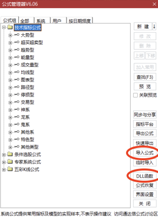

在下拉框中找到标有 **“第2号”** 的插槽，点击 **“打开绑定”** 按钮，浏览到 `T0002\dlls\` 子目录，选中 `tdx_zen.dll` 后点击“打开”：

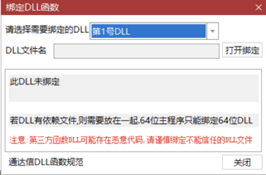

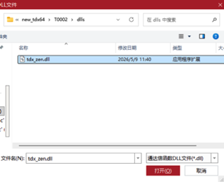

此时可能会弹出安全提示，这是通达信对第三方插件的常规提示，只要下载来源为官方作者即可放心点击确认。

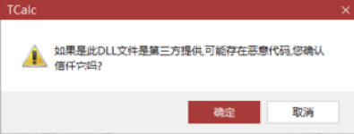

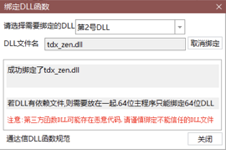

首次绑定时，会弹出浏览器展示用户协议。只有阅读完全文并点击同意后方能使用本插件。**此弹窗只展示一次**。点击协议最下方的"同意"后，第 2 号插槽会显示 `tdx_zen.dll`。

如果是试用软件，此时会弹窗显示剩余试用天数提醒。

⬆ 回到目录

### 附录 A.4 通达信盘后数据下载说明

**下载步骤**：

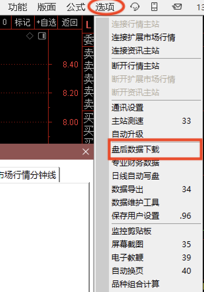

2. 在弹出的下载界面中，根据需要选择下载内容： - **日线数据**：勾选"沪深京日线"，下载所有 A 股的日线数据 - **5 分钟线数据**：勾选"沪深京分钟线"下的 **"5 分钟线数据"**（无需下载 1 分钟线，这是通达信软件自身的机制，5 倍数的分钟线通过 5 分钟线生成） - 点击 **"开始下载"** 即可

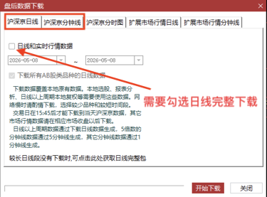

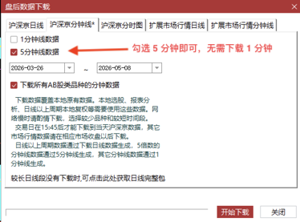

⬆ 回到目录